# Getting and cleaning data - Course Project

Remco Niggebrugge

01/14/2015

**This document is for me to keep track**, I do not think a RMarkdown file should be posted as part of this assignment.

These are the steps I am going to take.

**0** Libraries

```r
library(dplyr)
library(lattice)
```

**1** Set working directory to that with all raw data files:

```r
setwd("/home/remco/Desktop/data/small/")
```

**2** Read training files:

```r
subject      <- read.table("./train/subject_train.txt")
activity     <- read.table("./train/y_train.txt")
measurements <- read.table("./train/X_train.txt", sep="")
features     <- read.table("./features.txt")
```

**3** Assign column names:

```r
names(subject)      <- "subject"
names(activity)     <- "activity"
names(measurements) <- features[,2]    ## use 2nd column of features, first column has index
```

**4** Now simply bind the columns (pasting data.frames left-to-right)

```r
train_frame <- cbind(subject, activity, measurements)
```

**5** Now repeat same steps for the test dataset:

```r
subject      <- read.table("./test/subject_test.txt")
activity     <- read.table("./test/y_test.txt")
measurements <- read.table("./test/X_test.txt", sep="")
names(subject)      <- "subject"
names(activity)     <- "activity"
names(measurements) <- features[,2]    ## use 2nd column of features, first column has index

test_frame <- cbind(subject, activity, measurements)
```

**6** Now lets put the two sets together, using *rbind* to paste top-to-bottom:

```r
data <- rbind(train_frame, test_frame)
```

**7** The column names actually contain many characters we do not want there. Let’s clean:

```r
names       <- names(data)
names       <- gsub("[)(,\\-]","", names)
names(data) <- names
```

Also add meaning full labels to activitiy values:

```r
activity_labels    <-read.table("./activity_labels.txt")
activity_labels$V2 <-tolower(activity_labels$V2)
data$activity      <- factor(data$activity, labels=activity_labels[,2])
```

**8** Now find the columns we want to keep:

Let us start by creating a list of all features with name containing *‘mean’*, *‘Mean’* or *‘std’*:

```r
columns <- grep("[Mm]ean|std", features[,2])
columns <- columns +2       # accounting for the added activity and subject columns
columns <- c(1,2,columns)   # that subsequently need to be added!!
```

Now we are ready to strip our dataset, only keeping those values we are interested in:

```r
data <- data[,columns]
dim(data)
```

```
## [1] 10299    88
```

**9** Group!

```r
new_data_set <- group_by(data, subject, activity) %>% summarise_each(funs(mean))
```

And examine:

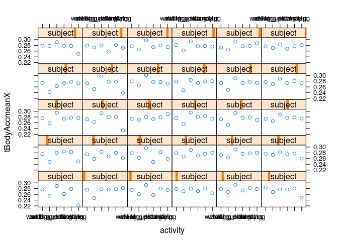

```r
with(new_data_set, xyplot(tBodyAccmeanX ~  activity | subject ))
```

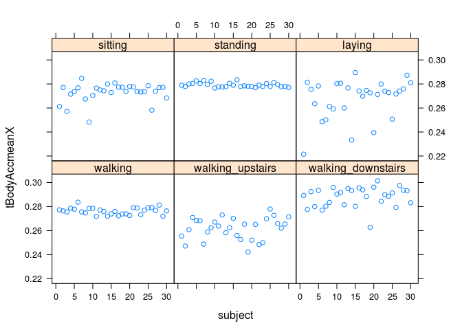

```r
with(new_data_set, xyplot(tBodyAccmeanX ~  subject | activity ))
```

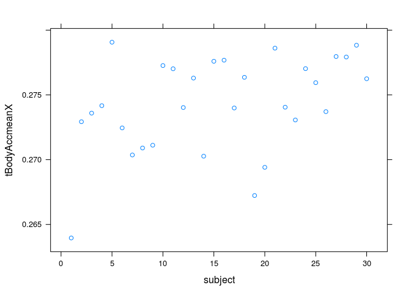

```r
#str(new_data_set)
#summary(new_data_set)
#new_data_set

g <- group_by(new_data_set, subject) %>% summarise_each(funs(mean))
with(g, xyplot(tBodyAccmeanX ~ subject))
```